# Zepto product insight & price insight

```python
import pandas as pd
import os
import matplotlib.pyplot as plt
import seaborn as sns
sns.set(style="whitegrid")
import plotly.express as px
from IPython.display import display, HTML
```

```python
zep=pd.read_csv("F:\\My files\\Rainman consulting task\\zepto product_price insight\\zepto_v1_csv.csv")
```

```python
zep.info()
```

```
<class 'pandas.core.frame.DataFrame'>
RangeIndex: 3732 entries, 0 to 3731
Data columns (total 9 columns):
 #   Column                  Non-Null Count  Dtype
---  ------                  --------------  -----
 0   Category                3732 non-null   object
 1   name                    3732 non-null   object
 2   mrp                     3732 non-null   int64
 3   discountPercent         3732 non-null   int64
 4   availableQuantity       3732 non-null   int64
 5   discountedSellingPrice  3732 non-null   int64
 6   weightInGms             3732 non-null   int64
 7   outOfStock              3732 non-null   bool
 8   quantity                3732 non-null   int64
dtypes: bool(1), int64(6), object(2)
memory usage: 237.0+ KB
```

```python
zep.shape
```

```
(3732, 9)
```

```python
zep.head(3)
```

|  | Category | name | mrp | discountPercent | availableQuantity | discountedSellingPrice | weightInGms | outOfStock | quantity |
| --- | --- | --- | --- | --- | --- | --- | --- | --- | --- |
| 0 | Fruits & Vegetables | Onion | 2500 | 16 | 3 | 2100 | 1000 | False | 1 |
| 1 | Fruits & Vegetables | Tomato Hybrid | 4200 | 16 | 3 | 3500 | 1000 | False | 1 |
| 2 | Fruits & Vegetables | Tender Coconut | 5100 | 15 | 3 | 4300 | 58 | False | 1 |

```python
zep.columns.values
```

```
array(['Category', 'name', 'mrp', 'discountPercent', 'availableQuantity',
       'discountedSellingPrice', 'weightInGms', 'outOfStock', 'quantity'],
      dtype=object)
```

```python
# Clean columns
zep.columns = [col.strip().lower().replace(" ", "_") for col in zep.columns]
```

```python
# Ensure numeric columns
numeric_columns = ['mrp', 'discountedsellingprice', 'discountpercent', 'availablequantity', 'quantity']
zep[numeric_columns] = zep[numeric_columns].apply(pd.to_numeric, errors='coerce')
```

# 1. Average Discount per Category

This plot shows which product categories offer the highest average discounts. A higher value indicates a promotional focus or lower pricing strategy in that category.

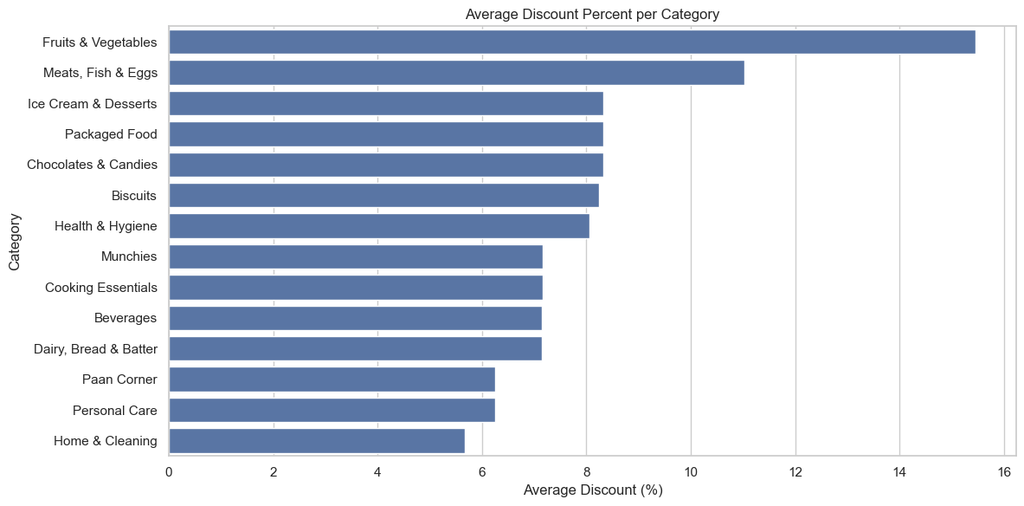

```python
# Average discount per category
plt.figure(figsize=(12, 6))
avg_discount = zep.groupby('category')['discountpercent'].mean().sort_values(ascending=False)
sns.barplot(x=avg_discount.values, y=avg_discount.index)
plt.title("Average Discount Percent per Category")
plt.xlabel("Average Discount (%)")
plt.ylabel("Category")
plt.tight_layout()
plt.show()
```

# 2. Product Count per Category

This plot reveals the distribution of product volume across categories. Categories with the highest count indicate more product variety or emphasis in Zepto's inventory.

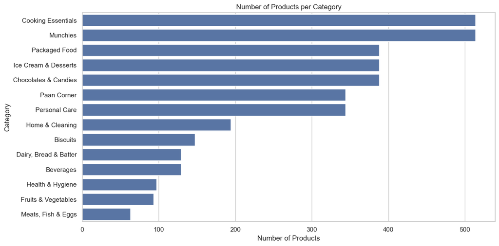

```python
# Product count per category
plt.figure(figsize=(12, 6))
product_count = zep['category'].value_counts()
sns.barplot(x=product_count.values, y=product_count.index)
plt.title("Number of Products per Category")
plt.xlabel("Number of Products")
plt.ylabel("Category")
plt.tight_layout()
plt.show()
```

# 3. Sunburst Plot

Which categories have more high-discount items? Which discount ranges contribute most to out-of-stock issues?

```python
# Create discount bucket
zep['discount_bucket'] = pd.cut(zep['discountpercent'], bins=[0, 10, 20, 30, 50, 100],
                                labels=['0-10%', '11-20%', '21-30%', '31-50%', '51%+'])

# Convert outofstock to readable label
zep['stock_status'] = zep['outofstock'].map({False: 'In Stock', True: 'Out of Stock'})

# Drop rows with missing path components
sunburst_zep = zep.dropna(subset=['category', 'discount_bucket', 'stock_status'])

# Create Sunburst Plot
fig = px.sunburst(sunburst_zep,
                  path=['category', 'discount_bucket', 'stock_status'],
                  values='availablequantity',
                  color='discount_bucket',
                  title="Sunburst: Category → Discount → Stock Status",
                  height=600)
fig.show()
```

[interactive chart not shown]

# 4. Top Categories by Total Stock

Shows how stocked each category is?

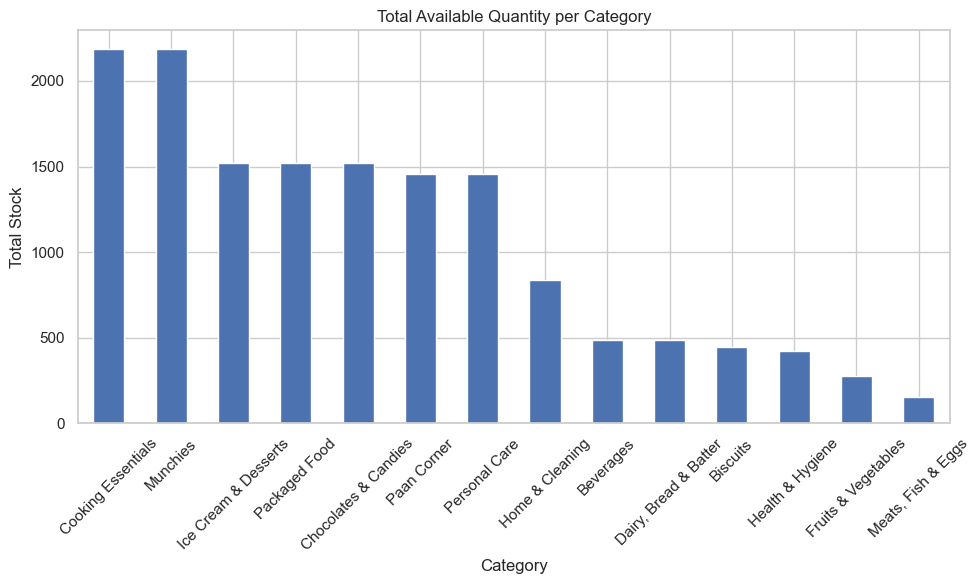

```python
# Top Categories by Total Stock
zep.groupby('category')['availablequantity'].sum().sort_values(ascending=False).plot(kind='bar', figsize=(10,6))
plt.title("Total Available Quantity per Category")
plt.xlabel("Category")
plt.ylabel("Total Stock")
plt.xticks(rotation=45)
plt.tight_layout()
plt.show()
```

# 5.Top 10 Discounted Products

This visualization highlights individual products with the steepest discounts, which can indicate overstock, short shelf life, or aggressive pricing.

[output not shown]

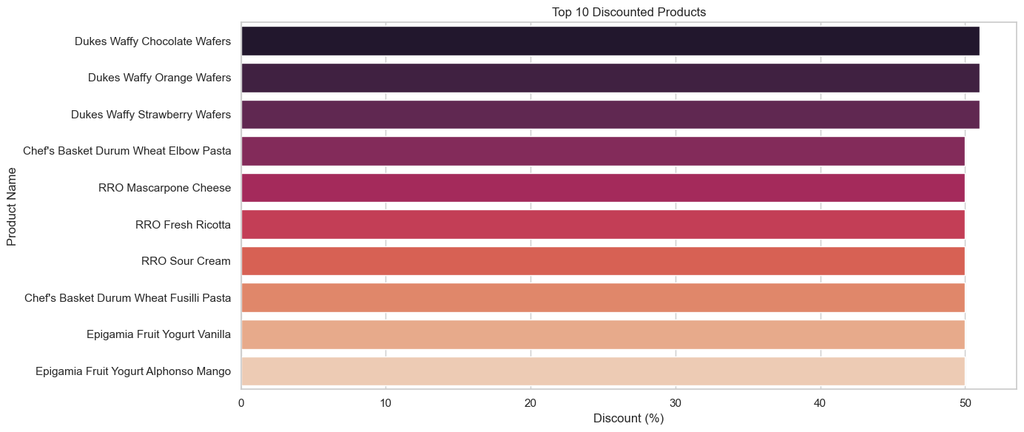

```python
top_discounts = zep.sort_values(by='discountpercent', ascending=False).head(10)
plt.figure(figsize=(14, 6))
sns.barplot(x='discountpercent', y='name', data=top_discounts, palette="rocket")
plt.title("Top 10 Discounted Products")
plt.xlabel("Discount (%)")
plt.ylabel("Product Name")
plt.tight_layout()
plt.show()
```

# 6. Price Distribution per Category (Boxplot)

Boxplots illustrate how prices are spread across categories. Wider spreads suggest varied product pricing; outliers may represent premium items.

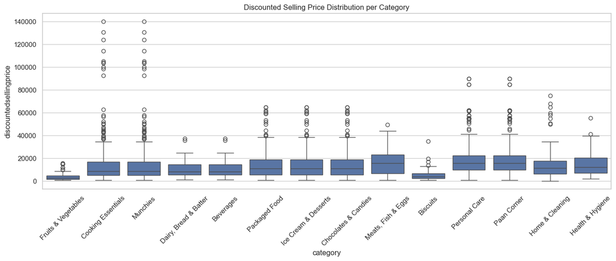

```python
# Box Plot
plt.figure(figsize=(14, 6))
sns.boxplot(data=zep, x='category', y='discountedsellingprice')
plt.title("Discounted Selling Price Distribution per Category")
plt.xticks(rotation=45)
plt.tight_layout()
plt.show()
```

# 7. MRP vs.Discounted Price (Scatter)

This scatter plot shows the relationship between original and discounted prices. Points below the diagonal imply effective discounts being applied.

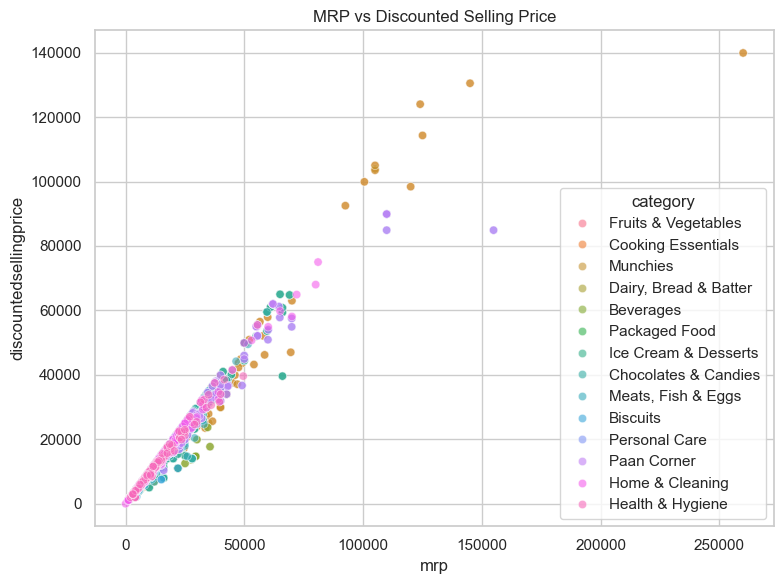

```python
# Scatter Plot: MRP vs Discounted Price
plt.figure(figsize=(8, 6))
sns.scatterplot(data=zep, x='mrp', y='discountedsellingprice', hue='category', alpha=0.6)
plt.title("MRP vs Discounted Selling Price")
plt.tight_layout()
plt.show()
```

# 8. Discount Percent vs. Stock Quantity (Scatter)

This plot helps assess whether larger discounts correlate with higher stock levels. This can reflect clearance strategies.

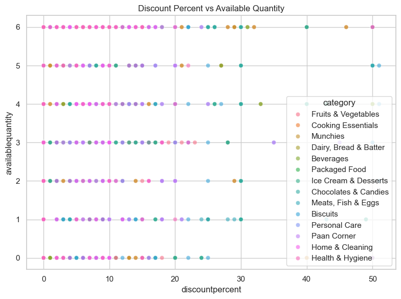

```python
# Scatter Plot: Discount vs Available Quantity
plt.figure(figsize=(8, 6))
sns.scatterplot(data=zep, x='discountpercent', y='availablequantity', hue='category', alpha=0.6)
plt.title("Discount Percent vs Available Quantity")
plt.tight_layout()
plt.show()
```

# 9. Price Difference Analysis

Gives insights into how much Zepto is discounting.

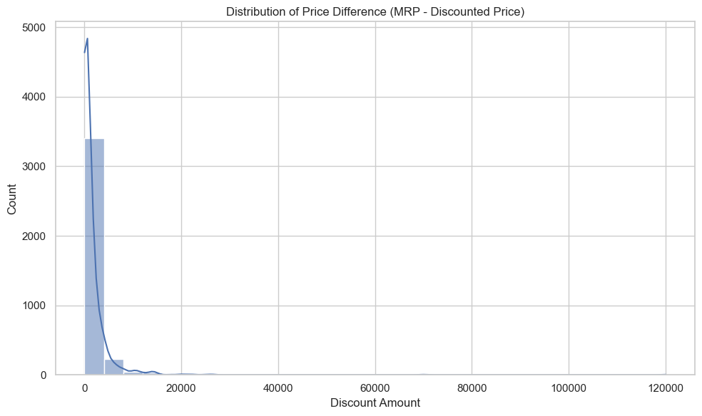

```python
# Price Difference Analysis
zep['price_diff'] = zep['mrp'] - zep['discountedsellingprice']
plt.figure(figsize=(10, 6))
sns.histplot(zep['price_diff'], bins=30, kde=True)
plt.title("Distribution of Price Difference (MRP - Discounted Price)")
plt.xlabel("Discount Amount")
plt.tight_layout()
plt.show()
```

# 10. Product Distribution by Category (Pie Chart)

Pie charts give a snapshot of how Zepto's offerings are split among categories, indicating focus areas.

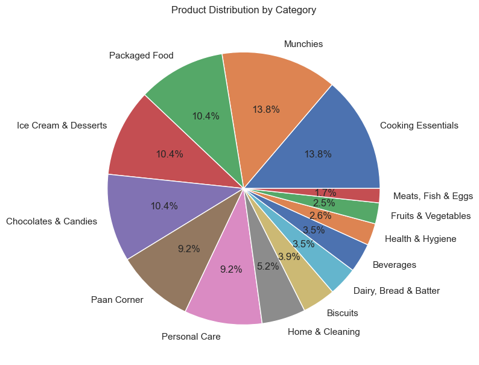

```python
# Pie Chart: Category share
zep['category'].value_counts().plot.pie(autopct='%1.1f%%', figsize=(8, 8))
plt.title("Product Distribution by Category")
plt.ylabel("")
plt.tight_layout()
plt.show()
```

# 11. Stock Availability (Pie Chart)

This shows the proportion of products in stock vs. out of stock. A high out-of-stock ratio could impact customer experience.

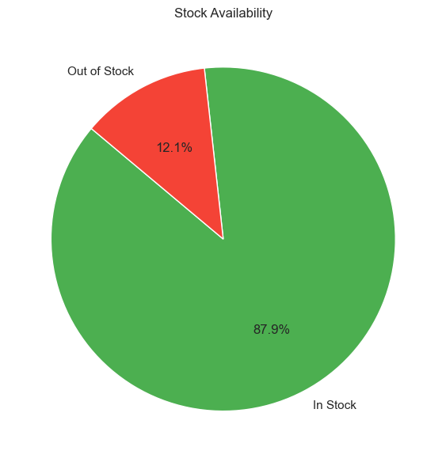

```python
# Count in-stock and out-of-stock items
stock_counts = zep['outofstock'].value_counts()
labels = ['In Stock', 'Out of Stock']
colors = ['#4caf50', '#f44336']  # Green and Red

# Plot pie chart
plt.figure(figsize=(6, 6))
plt.pie(stock_counts, labels=labels, autopct='%1.1f%%', startangle=140, colors=colors, wedgeprops={'edgecolor': 'white'})
plt.title("Stock Availability")
plt.tight_layout()
plt.show()
```

# 12. Discount Percent Distribution (Histogram)

This histogram helps understand how discounts are generally spread across products, revealing overall discounting intensity.

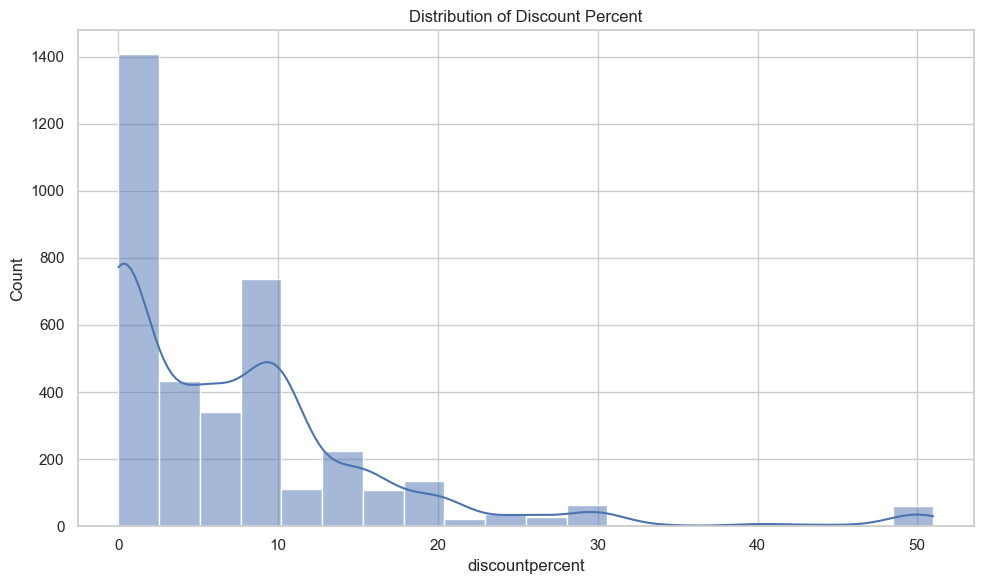

```python
# Histogram: Discount Distribution
plt.figure(figsize=(10, 6))
sns.histplot(zep['discountpercent'], bins=20, kde=True)
plt.title("Distribution of Discount Percent")
plt.tight_layout()
plt.show()
#/usr/local/lib/python3.11/dist-packages/seaborn/_oldcore.py:1119: FutureWarning:

#use_inf_as_na option is deprecated and will be removed in a future version. Convert inf values to NaN before operating instead.
```

# 13. MRP Value Distribution (Histogram)

Shows how MRPs are distributed across the inventory, providing insight into price ranges Zepto targets.

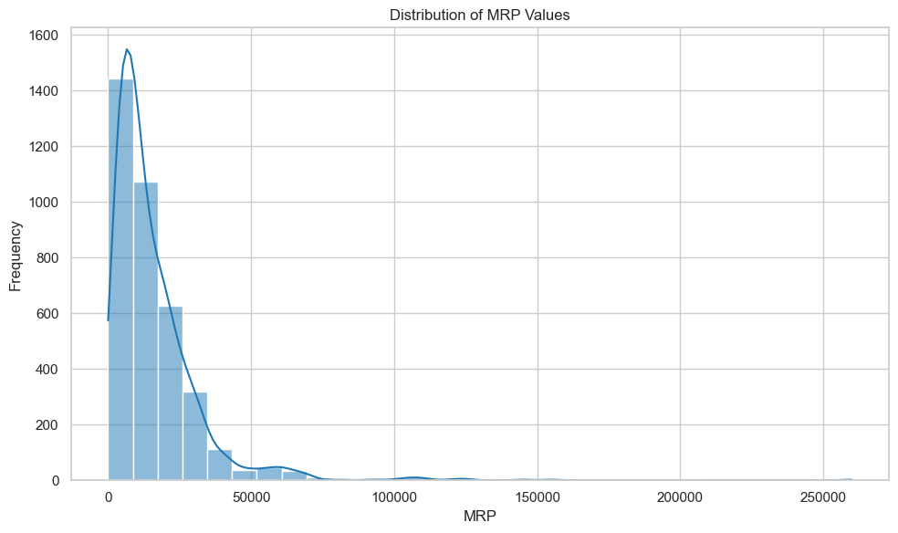

```python
# Ensure 'mrp' column is numeric
zep['mrp'] = pd.to_numeric(zep['mrp'], errors='coerce')

# Drop rows with missing or invalid MRP values
valid_mrp = zep['mrp'].dropna()

# Plot histogram
plt.figure(figsize=(10, 6))
sns.histplot(valid_mrp, bins=30, kde=True, color='#1f77b4')
plt.title("Distribution of MRP Values")
plt.xlabel("MRP")
plt.ylabel("Frequency")
plt.tight_layout()
plt.show()

#/usr/local/lib/python3.11/dist-packages/seaborn/_oldcore.py:1119: FutureWarning:

#use_inf_as_na option is deprecated and will be removed in a future version. Convert inf values to NaN before operating instead.
```

# 14. Correlation Heatmap

This heatmap reveals how numerical features like price, discount, and quantity relate to one another. Useful for spotting patterns or dependencies.

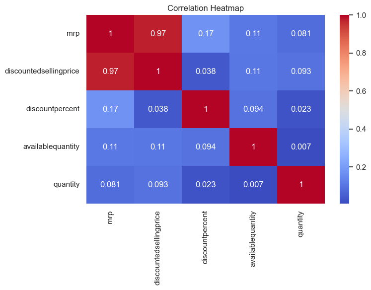

```python
# Heatmap: Correlation
plt.figure(figsize=(8, 6))
sns.heatmap(zep[numeric_columns].corr(), annot=True, cmap='coolwarm')
plt.title("Correlation Heatmap")
plt.tight_layout()
plt.show()
```

# 15. Violin Plot of Discounts by Category

Violin plots show both the range and concentration of discount values. Some categories may have narrow pricing strategies, others broader.

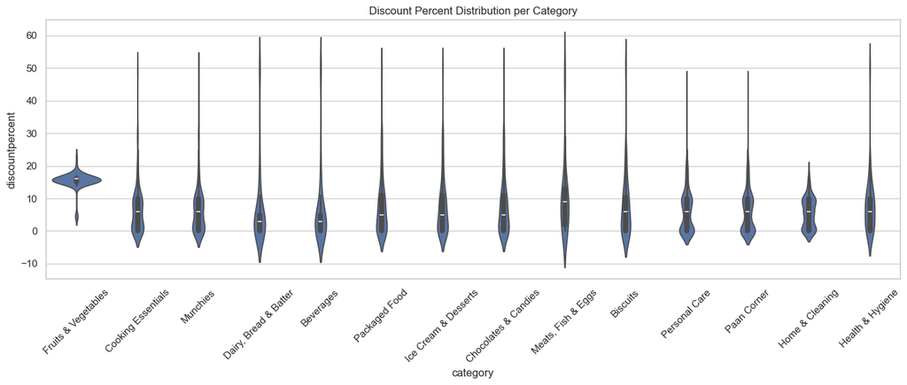

```python
# Define and create the output directory if it doesn't exist
output_dir = "plots"
os.makedirs(output_dir, exist_ok=True)   # Works the same on Windows

# Violin Plot: Discount % per category
plt.figure(figsize=(14, 6))
sns.violinplot(data=zep, x='category', y='discountpercent')
plt.title("Discount Percent Distribution per Category")
plt.xticks(rotation=45)
plt.tight_layout()

plt.savefig(os.path.join(output_dir, "violin_discount_by_category.png"))
plt.show()
```

# 16. Bubble Chart - Discount vs Price vs Stock

This multi-variable plot visualizes how discount % and price relate, while bubble size shows available stock. It’s great for identifying heavily stocked, discounted items.

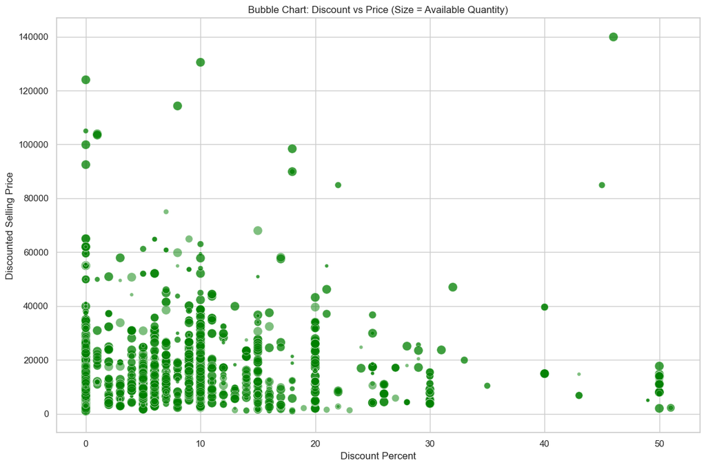

```python
# Bubble Chart: Discount % vs Price with bubble size = available quantity
plt.figure(figsize=(12, 8))
bubble = zep.copy()
plt.scatter(bubble['discountpercent'], bubble['discountedsellingprice'],
            s=bubble['availablequantity']*20, alpha=0.5, c='green', edgecolors='w', linewidth=0.5)
plt.xlabel("Discount Percent")
plt.ylabel("Discounted Selling Price")
plt.title("Bubble Chart: Discount vs Price (Size = Available Quantity)")
plt.tight_layout()
plt.savefig(f"{output_dir}/bubble_discount_vs_price.png")
plt.show()
```

# 17.Quantity Pack Analysis

Finds most frequent pack sizes

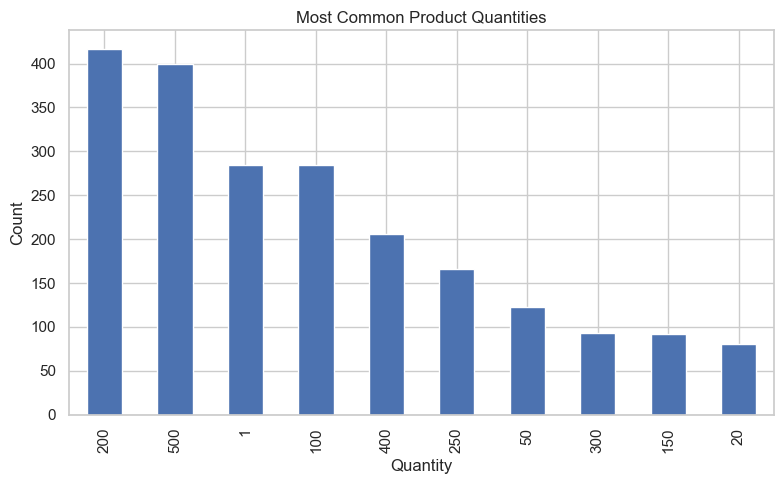

```python
# Quantity Pack Analysis
zep['quantity'].value_counts().head(10).plot(kind='bar', figsize=(8,5))
plt.title("Most Common Product Quantities")
plt.xlabel("Quantity")
plt.ylabel("Count")
plt.tight_layout()
plt.show()
```

# 18. Sorted Discount Trend (Line Plot)

```python
Displays the entire range of discounts sorted in descending order. It helps visualize pricing aggressiveness across products.
```

[output not shown]

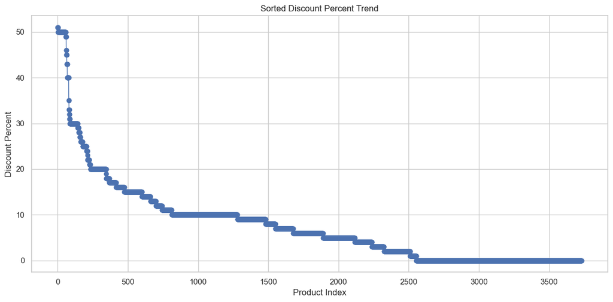

```python
# Line Chart: Discount trend (sorted)
sorted_discounts = zep.sort_values(by='discountpercent', ascending=False)['discountpercent'].reset_index(drop=True)
plt.figure(figsize=(12, 6))
plt.plot(sorted_discounts, marker='o', linewidth=1)
plt.title("Sorted Discount Percent Trend")
plt.xlabel("Product Index")
plt.ylabel("Discount Percent")
plt.tight_layout()
plt.savefig(f"{output_dir}/line_discount_trend.png")
plt.show()
```